# Concrete_FMSTProject

# Linear Regression Model

```python
from sklearn.preprocessing import MinMaxScaler
mms = MinMaxScaler()
#standard scale each column in training dataset and then do linear regression to analyse the factor important
mms.fit(X_train)  # scaled the indepedant columns
lr_model = LinearRegression()  #build a linear regression model
X_train_scaled=mms.transform(X_train)  #transform the x-scaled values
lr_model.fit(X_train_scaled,y_train)   #fit the model
lr_predictions=lr_model.predict(mms.transform(X_test))
```

```python
X_test_scaled=mms.transform(X_test)
```

```python
X_train_scaled=pd.DataFrame(X_train_scaled,columns=X.columns)
for idx, col_name in enumerate(X_train_scaled.columns):
    print("The coefficient for {} is {}".format(col_name, lr_model.coef_[idx]))
```

```
The coefficient for cement is 54.171293761842215
The coefficient for slag is 38.23937269668397
The coefficient for ash is 18.207273175830007
The coefficient for water is -18.549908912777266
The coefficient for superplastic is 9.347646331979906
The coefficient for coarseagg is 6.503222259861555
The coefficient for fineagg is 9.348890475706611
The coefficient for age is 41.81887627926861
```

```python
#Conclude on feature importance
#This means that a unit(kg) increase in "cement", there is a increase of 54.17 units in the concrete composite strength as well
# after a year, there is an increase of 41.81 units in concrete composite strength
#So after seeing the magnitude of these coeffcients , imporrtance of variables in linear regression is
####   cement > age > slag > water> ash > fineagg > superplastic > coarseagg
```

```python
intercept =lr_model.intercept_

print("The intercept for linear regression model is {}".format(intercept))
```

```
The intercept for linear regression model is -4.4476402777527255
```

```python
#Evaluation metrics for regression problems:MSE and RMSE
print('{} had Mean Squared Error of {}'.format('linear regression', mean_squared_error(y_test,lr_predictions)))
print('{} had Root Mean Squared Error of {}'.format('linear regression', r2_score(y_test, lr_predictions)))
```

```
linear regression had Mean Squared Error of 110.7714520174897
linear regression had Root Mean Squared Error of 0.5845101408706099
```

```python
X_test_scaled=pd.DataFrame(X_test_scaled,columns=X.columns)
X_test_scaled['cement']
```

```
0      0.851598
1      0.512557
2      0.147945
3      0.594977
4      0.314155
         ...
304    0.255251
305    0.426941
306    0.888128
307    0.121005
308    0.085845
Name: cement, Length: 309, dtype: float64
```

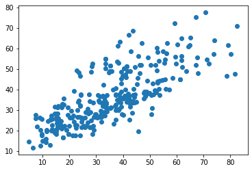

```python
#Since this is regression, plot the predicted y value vs actual y values for the test data
y_test=pd.DataFrame(y_test)

plt.scatter(y_test['strength'], lr_predictions)

#plt.scatter(X_test_scaled['cement'], y_test, s=10)
#plt.plot(X_test_scaled['cement'], lr_predictions, color='r')
#plt.show()
```

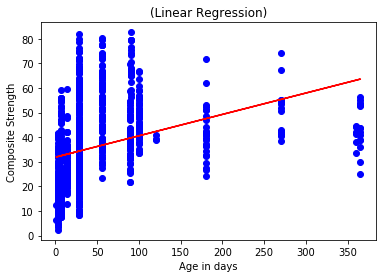

```python
from sklearn.linear_model import LinearRegression
lin_reg = LinearRegression()
x_new=condf["age"].values
x_new=pd.DataFrame(x_new)
y1=condf["strength"].values
lin_reg.fit(x_new, y1)

# Visualizing the Linear Regression results
def viz_linear():
    plt.scatter(x_new, y1, color='blue')
    plt.plot(x_new, lin_reg.predict(x_new), color='red')
    plt.title('(Linear Regression)')
    plt.xlabel('Age in days')
    plt.ylabel('Composite Strength')
    plt.show()
    return
viz_linear()
```

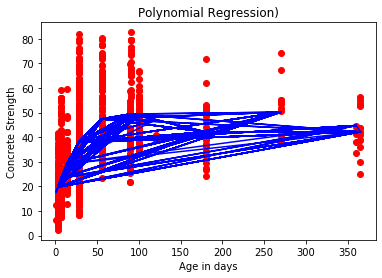

```python
#In another hand, we will build the Polynomial Regression model and visualize it to see the differences:
# Fitting Polynomial Regression to the dataset
from sklearn.preprocessing import PolynomialFeatures
poly_reg = PolynomialFeatures(degree=4)
X_poly = poly_reg.fit_transform(x_new)
pol_reg = LinearRegression()
pol_reg.fit(X_poly, y1)

# Visualizing the Polymonial Regression results
def viz_polymonial():
    plt.scatter(x_new, y1, color='red')
    plt.plot(x_new, pol_reg.predict(poly_reg.fit_transform(x_new)), color='blue')
    plt.title('Polynomial Regression)')
    plt.xlabel('Age in days')
    plt.ylabel('Concrete Strength')
    plt.show()
    return
viz_polymonial()
```

```python
#As we can see that age is a high non linear features with strength
```

There are many factors that may have contributed to this inaccuracy, for example

1. Bad assumptions: We made the assumption that this data has a linear relationship, but that might not be the case. Visualizing the data may help you determine that.
2. Poor features: The features we used may not have had a good enough correlation to the values we were trying to predict.

# Regularized RIDGE model

```python
ridge = Ridge(alpha=.3)
ridge.fit(X_train_scaled,y_train)
print ("Ridge model:", (ridge.coef_))
```

```
Ridge model: [ 49.73210463  33.92897586  15.35909021 -22.44920027   9.40873515
   3.36920943   4.80881067  40.93994484]
```

# Regularized LASSO model

```python
lasso = Lasso(alpha=0.1)
lasso.fit(X_train_scaled,y_train)
print ("Lasso model:", (lasso.coef_))

# Observe, many of the coefficients have become 0 indicating drop of those dimensions from the model i.e.coarseagg,fineagg
```

```
Lasso model: [ 41.79430532  25.63765533   9.50105647 -23.18278587  10.55735997
  -0.          -0.          36.52202554]
```

# Let us compare their scores

```python
train_score=lr_model.score(X_train_scaled, y_train)
test_score=lr_model.score(X_test_scaled, y_test)

resultsDf = pd.DataFrame({'Method':['Linear Regression'],'Iteration':["1-with all columns"], 'Train Score': train_score,'Test Score':test_score})
resultsDf = resultsDf[['Method','Iteration' ,'Train Score','Test Score']]
resultsDf
```

|  | Method | Iteration | Train Score | Test Score |
| --- | --- | --- | --- | --- |
| 0 | Linear Regression | 1-with all columns | 0.627147 | 0.58451 |

```python
train_score=ridge.score(X_train_scaled, y_train)
test_score=ridge.score(X_test_scaled, y_test)
tempDf = pd.DataFrame({'Method':['Regularized Ridge Model'], 'Iteration':["1-with all columns"], 'Train Score': train_score,'Test Score':test_score})
resultsDf = resultsDf.append(tempDf,ignore_index=True)

train_score=lasso.score(X_train_scaled, y_train)
test_score=lasso.score(X_test_scaled, y_test)
tempDf = pd.DataFrame({'Method':['Regularized Lasso Model'], 'Iteration':["1-with all columns"], 'Train Score': train_score,'Test Score':test_score})
resultsDf = resultsDf.append(tempDf,ignore_index=True)
resultsDf
```

|  | Method | Iteration | Train Score | Test Score |
| --- | --- | --- | --- | --- |
| 0 | Linear Regression | 1-with all columns | 0.627147 | 0.584510 |
| 1 | Regularized Ridge Model | 1-with all columns | 0.626574 | 0.585189 |
| 2 | Regularized Lasso Model | 1-with all columns | 0.617593 | 0.580914 |

```python
resultsDf[:-3]  #.drop(resultsDf.index[2])
```

|  | Method | Iteration | Train Score | Test Score |
| --- | --- | --- | --- | --- |

# Conclusion from linear regressor:

```python
    # as we have seen that we are getting very bad score from the linear regressor so this also justify that our model is nmot a linear model beause it has some non-linear features
    #so to get the good results let us analyse the non linear regressor like decision tree regressor or random tree that will provide us the information on important features and we can skip the non value added features
```

# DecisionTree Regressor

```python
from sklearn.tree import DecisionTreeRegressor
dt_model = DecisionTreeRegressor()
```

```python
dt_model.fit(X_train_scaled, y_train)
```

```
DecisionTreeRegressor(ccp_alpha=0.0, criterion='mse', max_depth=None,
                      max_features=None, max_leaf_nodes=None,
                      min_impurity_decrease=0.0, min_impurity_split=None,
                      min_samples_leaf=1, min_samples_split=2,
                      min_weight_fraction_leaf=0.0, presort='deprecated',
                      random_state=None, splitter='best')
```

```python
print (pd.DataFrame(dt_model.feature_importances_, columns = ["Important features"], index = X_train.columns))
```

```
              Important features
cement                  0.388419
slag                    0.127220
ash                     0.007126
water                   0.099628
superplastic            0.030798
coarseagg               0.021697
fineagg                 0.019532
age                     0.305580
```

```python
#for decision tree regressor also, we are getting important features as cement,age,water and slag while other features we can drop in iteration 2
```

```python
train_score=dt_model.score(X_train_scaled, y_train)
test_score=dt_model.score(X_test_scaled, y_test)
tempDf = pd.DataFrame({'Method':['Decision Tree Regressor'], 'Iteration':["1-with all columns"], 'Train Score': train_score,'Test Score':test_score})
resultsDf = resultsDf.append(tempDf,ignore_index=True)
resultsDf
```

|  | Method | Iteration | Train Score | Test Score |
| --- | --- | --- | --- | --- |
| 0 | Linear Regression | 1-with all columns | 0.627147 | 0.584510 |
| 1 | Regularized Ridge Model | 1-with all columns | 0.626574 | 0.585189 |
| 2 | Regularized Lasso Model | 1-with all columns | 0.617593 | 0.580914 |
| 3 | Decision Tree Regressor | 1-with all columns | 0.995082 | 0.872980 |